### 1. 1. Mental Health Clinics

##### a. This data set is a survey of every known healthcare facility that offers mental health services in the United States in 2015. Navigate to https://datafiles.samhsa.gov/study-dataset/nationalmental-health-services-survey-2015-n-mhss-2015-ds0001-nid17098 and select the R download. Look through the codebook PDF for an explanation on certain variables. Upon opening the RDA file, the data set should be inserted into your global environment, which you can then reference.

```r
load("~/SMU/Summer 2019/Doing Data Science/Wk 6 HW/N-MHSS-2015-DS0001-bndl-data-r/N-MHSS-2015-DS0001-data/N-MHSS-2015-DS0001-data-r.rda")
```

##### b. Please create code which lists the State abbreviations without their counts, one abbreviation per State value. It does not have to in data frame format. A vector is fine

```r
levels(mh2015_puf$LST)
```

```
##  [1] "AK    " "AL    " "AR    " "AS    " "AZ    " "CA    " "CO    "
##  [8] "CT    " "DC    " "DE    " "FL    " "GA    " "GU    " "HI    "
## [15] "IA    " "ID    " "IL    " "IN    " "KS    " "KY    " "LA    "
## [22] "MA    " "MD    " "ME    " "MI    " "MN    " "MO    " "MS    "
## [29] "MT    " "NC    " "ND    " "NE    " "NH    " "NJ    " "NM    "
## [36] "NV    " "NY    " "OH    " "OK    " "OR    " "PA    " "PR    "
## [43] "RI    " "SC    " "SD    " "TN    " "TX    " "UT    " "VA    "
## [50] "VI    " "VT    " "WA    " "WI    " "WV    " "WY    "
```

```r
unique(mh2015_puf$LST)
```

```
##  [1] AL     AK     AZ     AR     CA     CO     CT     DE     DC     FL
## [11] GA     HI     ID     IL     IN     IA     KS     KY     LA     ME
## [21] MD     MA     MI     MN     MS     MO     MT     NE     NV     NH
## [31] NJ     NM     NY     NC     ND     OH     OK     OR     PA     RI
## [41] SC     SD     TN     TX     UT     VT     VA     WA     WV     WI
## [51] WY     AS     GU     PR     VI
## 55 Levels: AK     AL     AR     AS     AZ     CA     CO     ... WY
```

##### c. Filter the data.frame from 1A. We are only interested in the Veterans Administration (VA) medical centers in the mainland United States-create a listing of counts of these centers by state, including only mainland locations. Alaska, Hawaii, and U.S. territories should be omitted. DC, while not a state, is in the mainland, so it should remain included. Convert this to data.frame()

```r
df <- as.data.frame(table(mh2015_puf$LST))
df2<- df[-c(2,4,13,14,8,2,42,50),]
names(df2)[names(df2) == "Var1"] <- "Abbrev"
names(df2)[names(df2) == "Freq"] <- "Centers"
```

##### d. Create a ggplot barchart of this filtered data set. Vary the bar’s colors by what State it has listed. Give it an appropriately professional title that is centered. Make sure you have informative axis labels. The State axis should be readable, not layered over each other. You’re welcome to have a legend or not.

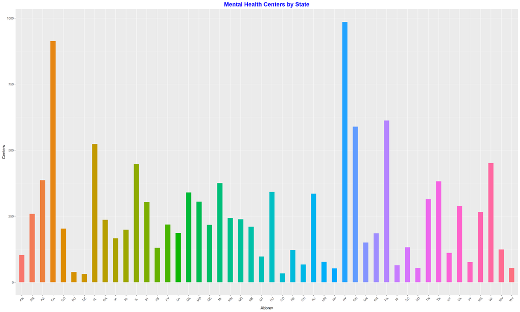

```r
library(ggplot2)
 r <- ggplot(data=df2,aes(x=Abbrev,y=Centers,fill=Abbrev))+ geom_bar(stat="identity",width= 0.5)+ theme(axis.text.x=element_text(angle=45)) + theme(legend.position = "none")
 r + ggtitle ("Mental Health Centers by State") + theme(plot.title = element_text(color = "Blue",size = 16,face= "bold",hjust = 0.5))
```

```r
df3 <- read.csv(file="C:/Users/sojha.WVOFFICE.000/Documents/SMU/Summer 2019/Doing Data Science/Wk 6 HW/statesize.csv",header=TRUE,sep=",")
```

##### a. This graph (1D) might be somewhat misleading, as bigger states may have more hospitals, but could be more sparsely located. Read statesize.csv into your R environment. This contains essentially a vector of square miles for each state. In trying to merge it with your data.frame() from 1C, you find that they don’t match. Use paste() on your LST column in 1C to see what the matter is, and write what you observe in a comment.

```r
paste(df2$Abbrev)
```

```
##  [1] "AK    " "AR    " "AZ    " "CA    " "CO    " "DC    " "DE    "
##  [8] "FL    " "GA    " "IA    " "ID    " "IL    " "IN    " "KS    "
## [15] "KY    " "LA    " "MA    " "MD    " "ME    " "MI    " "MN    "
## [22] "MO    " "MS    " "MT    " "NC    " "ND    " "NE    " "NH    "
## [29] "NJ    " "NM    " "NV    " "NY    " "OH    " "OK    " "OR    "
## [36] "PA    " "RI    " "SC    " "SD    " "TN    " "TX    " "UT    "
## [43] "VA    " "VT    " "WA    " "WI    " "WV    " "WY    "
```

##### b. Correct the problem with the LST column using any method in R that is programmatic and easily understandable. Once you have made these state abbreviations identical to statesize.csv’s Abbrev column, merge the data.frame() from 1C and statesize.csv in order to add size information.

```r
df2$Abbrev <- strtrim(df2$Abbrev,2)
MergedDF <- merge(x=df3,y=df2,by.x="Abbrev",by.y="Abbrev")
MergedDF
```

```
##    Abbrev      StateName SqMiles    Region Centers
## 1      AK         Alaska  570374      West     103
## 2      AR       Arkansas   52075     South     259
## 3      AZ        Arizona  113642      West     386
## 4      CA     California  155973      West     913
## 5      CO       Colorado  103730      West     203
## 6      DE       Delaware    1955     South      31
## 7      FL        Florida   53997     South     523
## 8      GA        Georgia   57919     South     236
## 9      IA           Iowa   55875   Midwest     166
## 10     ID          Idaho   82751      West     199
## 11     IL       Illinois   55593   Midwest     447
## 12     IN        Indiana   35870   Midwest     304
## 13     KS         Kansas   81823   Midwest     130
## 14     KY       Kentucky   39732     South     218
```

[output cut: 33 more lines]

##### c. Calculate a new variable in your combined data.frame() which indicates the VA hospitals per thousand square miles.

```r
MergedDF$CountPerKMiles = MergedDF$Centers / (MergedDF$SqMiles / 1000)
MergedDF$CountPerKMiles
```

```
##  [1]  0.1805833  4.9735958  3.3966315  5.8535772  1.9570038 15.8567775
##  [7]  9.6857233  4.0746560  2.9709172  2.4048048  8.0405806  8.4750488
## [13]  1.5887953  5.4867613  4.2693844 43.3784129 31.2020460  7.0306172
## [19]  6.6325899  3.0521120  3.4543818  4.4762757  0.6664102  7.0199926
## [25]  0.4783025  1.5869299  7.4701750 45.1543335  0.6344498  0.4735625
## [31] 20.8580383 14.3823407  2.1840737  1.9270231 13.6546185 61.2440191
## [37]  4.3837800  0.7114812  7.6176613  1.4584940  1.3508909  7.2983484
## [43]  8.2171046  3.9950737  8.3035681  5.1480051  0.5560991
```

##### d. Create another ggplot which considers the VAs per square thousand miles, rather than just frequency. . Make sure the State axis is readable, like before. Change the title and axes as appropriate.

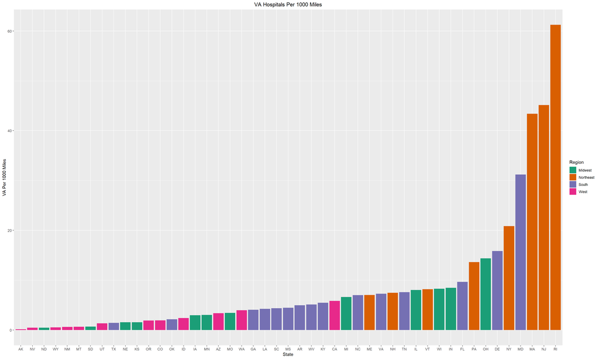

```r
ggplot(data=MergedDF,aes(x=reorder(Abbrev,CountPerKMiles),y=CountPerKMiles,fill=Region)) + geom_bar(stat="identity",show.legend = TRUE) + labs(x="State",y="VA Per 1000 Miles",title="VA Hospitals Per 1000 Miles") + theme(plot.title=element_text(hjust = 0.5))+scale_fill_brewer(palette="Dark2")
```

##### e. What patterns do you see? By this metric, is there any region that seems relatively high for VA medical centers per thousand square miles? How about low? Given these data, what advice might you give your boss before you start modeling (and why)?

There are alot of smaller states with alot of VA hospitals like Rode Island which has the most. There are not alot of VA hospitals in West but Northeast has the highest out of the 4 regions.

**Recomendation** : Because of West Region not having alot of VA hospitals, recommendation to build significantly more in that region to provide care and support for the Veterans.**

https://github.com/sandman1145/SMU-MSDS-6306/tree/Homework